# Analyzing the effectiveness of Training on Attrition

Ralitza Mondal

# 1 Clear the environment and load packages

```r
# Clear environment of variables and functions
rm(list = ls(all = TRUE))

# Clear environmet of packages
if(is.null(sessionInfo()$otherPkgs) == FALSE)lapply(paste("package:", names(sessionInfo()$otherPkgs), sep=""), detach, character.only = TRUE, unload = TRUE)
```

```r
library(tidyverse)
library(scales)
library(gridExtra)
library(janitor)
library(knitr)
library(GGally)
```

```r
library(stringr)
library(plotly)
library(cowplot)
library(kableExtra)
library(readxl)
library(corrplot)
```

# 2 Load the data

Load the data

```r
df<-read_excel('HR_data.xlsx')
```

```
## readxl works best with a newer version of the tibble package.
## You currently have tibble v1.4.2.
## Falling back to column name repair from tibble <= v1.4.2.
## Message displays once per session.
```

# 3 Base EDA Step 1: Univariate non-graphical EDA

Check the dfa type

```r
str(df)
```

```
## Classes 'tbl_df', 'tbl' and 'data.frame':    1470 obs. of  35 variables:
##  $ Age                     : num  41 49 37 33 27 32 59 30 38 36 ...
##  $ Attrition               : chr  "Yes" "No" "Yes" "No" ...
##  $ BusinessTravel          : chr  "Travel_Rarely" "Travel_Frequently" "Travel_Rarely" "Travel_Frequently" ...
##  $ DailyRate               : num  1102 279 1373 1392 591 ...
##  $ Department              : chr  "Sales" "Research & Development" "Research & Development" "Research & Development" ...
##  $ DistanceFromHome        : num  1 8 2 3 2 2 3 24 23 27 ...
##  $ Education               : num  2 1 2 4 1 2 3 1 3 3 ...
##  $ EducationField          : chr  "Life Sciences" "Life Sciences" "Other" "Life Sciences" ...
##  $ EmployeeCount           : num  1 1 1 1 1 1 1 1 1 1 ...
##  $ EmployeeNumber          : num  1 2 4 5 7 8 10 11 12 13 ...
##  $ EnvironmentSatisfaction : num  2 3 4 4 1 4 3 4 4 3 ...
##  $ Gender                  : chr  "Female" "Male" "Male" "Female" ...
##  $ HourlyRate              : num  94 61 92 56 40 79 81 67 44 94 ...
##  $ JobInvolvement          : num  3 2 2 3 3 3 4 3 2 3 ...
```

[output cut: 21 more lines]

check for nulls

```r
is.null(df)
```

```
## [1] FALSE
```

No nulls exist in the dfaframe.

```r
fsct_var<-c('BusinessTravel','Department','EducationField','Gender','JobRole','MaritalStatus','Over18','OverTime')
```

```r
df_num<-df
df_num$Gender <- str_replace(df_num$Gender, "Female", "1")
df_num$Gender <- str_replace(df_num$Gender, "Male", "2")

df_num$Attrition <- str_replace(df_num$Attrition, "No", "0")
df_num$Attrition <- str_replace(df_num$Attrition, "Yes", "1")

df_num$BusinessTravel <- str_replace(df_num$BusinessTravel, "Non-Travel", "0")
df_num$BusinessTravel <- str_replace(df_num$BusinessTravel, "Travel_Frequently", "2")
df_num$BusinessTravel <- str_replace(df_num$BusinessTravel, "Travel_Rarely", "1")


df_num$Department <- str_replace(df_num$Department, "Human Resources", "1")
df_num$Department <- str_replace(df_num$Department, "Research & Development", "2")
df_num$Department <- str_replace(df_num$Department, "Sales", "3")

df_num$Department <- str_replace(df_num$Department, "Human Resources", "1")
df_num$Department <- str_replace(df_num$Department, "Research & Development", "2")
df_num$Department <- str_replace(df_num$Department, "Sales", "3")

df_num$EducationField <- str_replace(df_num$EducationField, "Human Resources", "1")
df_num$EducationField <- str_replace(df_num$EducationField, "Life Sciences", "2")
df_num$EducationField <- str_replace(df_num$EducationField, "Marketing", "3")
df_num$EducationField <- str_replace(df_num$EducationField, "Medical", "4")
df_num$EducationField <- str_replace(df_num$EducationField, "Other", "5")
df_num$EducationField <- str_replace(df_num$EducationField, "Technical Degree", "6")

df_num$JobRole <- str_replace(df_num$JobRole, "Healthcare Representative", "1")
df_num$JobRole <- str_replace(df_num$JobRole, "Human Resources", "2")
df_num$JobRole <- str_replace(df_num$JobRole, "Laboratory Technician", "3")
df_num$JobRole <- str_replace(df_num$JobRole, "Manager", "4")
df_num$JobRole <- str_replace(df_num$JobRole, "Manufacturing Director", "5")
df_num$JobRole <- str_replace(df_num$JobRole, "Research Director", "6")
df_num$JobRole <- str_replace(df_num$JobRole, "Research Scientist", "7")
df_num$JobRole <- str_replace(df_num$JobRole, "Sales Executive", "8")
df_num$JobRole <- str_replace(df_num$JobRole, "Sales Representative", "9")


df_num$MaritalStatus <- str_replace(df_num$MaritalStatus, "Divorced", "1")
df_num$MaritalStatus <- str_replace(df_num$MaritalStatus, "Married", "2")
df_num$MaritalStatus <- str_replace(df_num$MaritalStatus, "Single", "3")

df_num$Over18 <- str_replace(df_num$Over18, "Y", "1")
df_num$OverTime <- str_replace(df_num$OverTime, "No", "0")
df_num$OverTime <- str_replace(df_num$OverTime, "Yes", "1")
```

```r
df_num <- df_num %>%
  mutate_if(is.character,as.numeric)
```

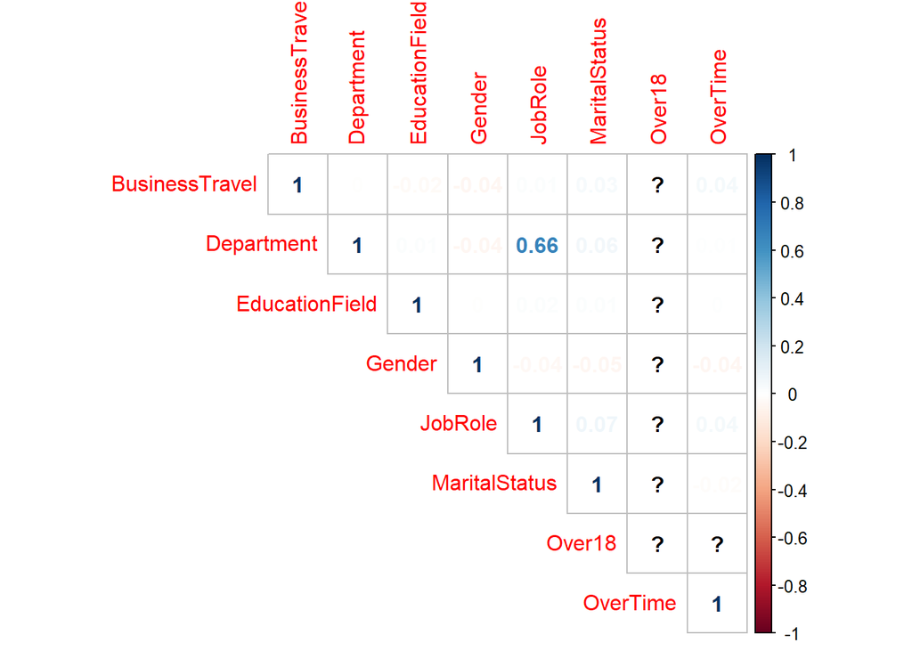

```r
#df_new <- bind_cols(df_num, df_fact)
df_num %>%
  select(fsct_var)%>%
  cor(use = "pairwise.complete.obs") %>%
  corrplot(method="number",type="upper")
```

Keeping department and Jobrole

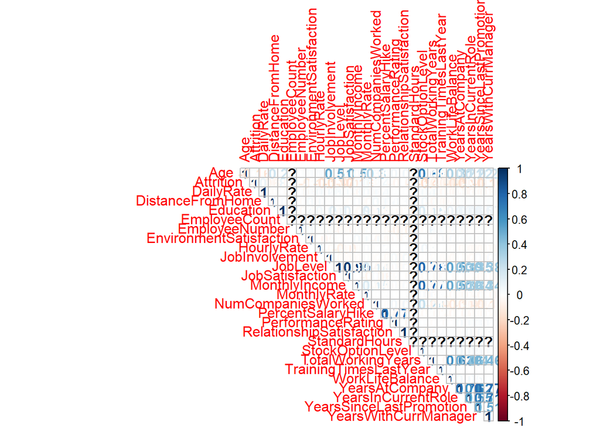

```r
df_num %>%
  select(-fsct_var)%>%
  cor(use = "pairwise.complete.obs") %>%
  corrplot(method="number",type="upper")
```

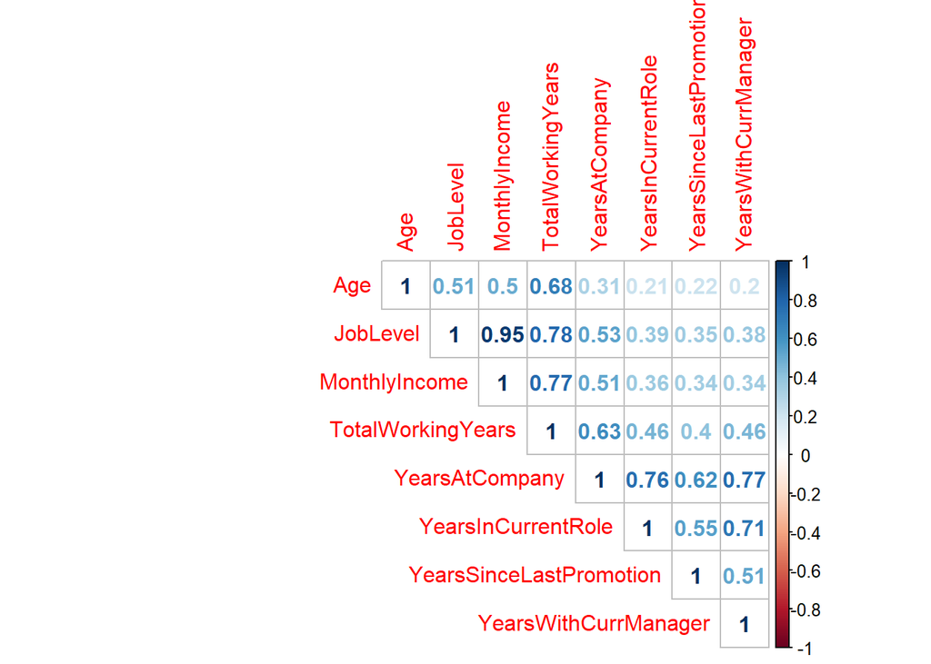

```r
df_num %>%
  select(c("Age","JobLevel","MonthlyIncome","TotalWorkingYears","YearsAtCompany","YearsInCurrentRole","YearsSinceLastPromotion","YearsWithCurrManager"))%>%
  cor(use = "pairwise.complete.obs") %>%
  corrplot(method="number",type="upper")
```

The important variables that are being kept are Attrition,Age,JobLevel,MonthlyIncome,TotalWorkingYears,YearsAtCompany,YearsInCurrentRole,YearsSinceLastPromotion, Department ,JobRole and YearsWithCurrManager

Change some variables into factors

```r
 df$Attrition<-as.factor(df$Attrition)
 levels(df$Attrition)<-c("0","1")

 df$BusinessTravel<-as.factor(df$BusinessTravel)
 df$Department<-as.factor(df$Department)
 df$EducationField<-as.factor(df$EducationField)
 df$Gender<-as.factor(df$Gender)
 df$JobRole<-as.factor(df$JobRole)
 df$MaritalStatus<-as.factor(df$MaritalStatus)
 df$Over18<-as.factor(df$Over18)
 df$OverTime<-as.factor(df$OverTime)
 df$Education<-as.factor(df$Education)
df$JobSatisfaction<-as.factor(df$JobSatisfaction)
 df$EnvironmentSatisfaction<-as.factor(df$EnvironmentSatisfaction)
 df$JobLevel<-as.factor(df$JobLevel)
 df$TrainingTimesLastYear<-as.factor(df$TrainingTimesLastYear)
 df$TrainingSet <- ifelse(levels(df$TrainingTimesLastYear)==0,"0","1")
 df$Training <- ifelse(levels(df$TrainingTimesLastYear)==0,"No","Yes")
```

Summary of the data

```r
summary(df)
```

```
##       Age        Attrition           BusinessTravel   DailyRate
##  Min.   :18.00   0:1233    Non-Travel       : 150   Min.   : 102.0
##  1st Qu.:30.00   1: 237    Travel_Frequently: 277   1st Qu.: 465.0
##  Median :36.00             Travel_Rarely    :1043   Median : 802.0
##  Mean   :36.92                                      Mean   : 802.5
##  3rd Qu.:43.00                                      3rd Qu.:1157.0
##  Max.   :60.00                                      Max.   :1499.0
##
##                   Department  DistanceFromHome Education
##  Human Resources       : 63   Min.   : 1.000   1:170
##  Research & Development:961   1st Qu.: 2.000   2:282
##  Sales                 :446   Median : 7.000   3:572
##                               Mean   : 9.193   4:398
##                               3rd Qu.:14.000   5: 48
##                               Max.   :29.000
##
##           EducationField EmployeeCount EmployeeNumber
##  Human Resources : 27    Min.   :1     Min.   :   1.0
##  Life Sciences   :606    1st Qu.:1     1st Qu.: 491.2
##  Marketing       :159    Median :1     Median :1020.5
##  Medical         :464    Mean   :1     Mean   :1024.9
##  Other           : 82    3rd Qu.:1     3rd Qu.:1555.8
##  Technical Degree:132    Max.   :1     Max.   :2068.0
##
##  EnvironmentSatisfaction    Gender      HourlyRate     JobInvolvement
##  1:284                   Female:588   Min.   : 30.00   Min.   :1.00
##  2:287                   Male  :882   1st Qu.: 48.00   1st Qu.:2.00
##  3:453                                Median : 66.00   Median :3.00
##  4:446                                Mean   : 65.89   Mean   :2.73
##                                       3rd Qu.: 83.75   3rd Qu.:3.00
##                                       Max.   :100.00   Max.   :4.00
##
##  JobLevel                      JobRole    JobSatisfaction  MaritalStatus
##  1:543    Sales Executive          :326   1:289           Divorced:327
##  2:534    Research Scientist       :292   2:280           Married :673
##  3:218    Laboratory Technician    :259   3:442           Single  :470
##  4:106    Manufacturing Director   :145   4:459
##  5: 69    Healthcare Representative:131
##           Manager                  :102
##           (Other)                  :215
```

[output cut: 33 more lines]

```
##  Min.   : 0.000          Min.   : 0.000       Length:1470
##  1st Qu.: 0.000          1st Qu.: 2.000       Class :character
##  Median : 1.000          Median : 3.000       Mode  :character
##  Mean   : 2.188          Mean   : 4.123
##  3rd Qu.: 3.000          3rd Qu.: 7.000
##  Max.   :15.000          Max.   :17.000
##
##    Training
##  Length:1470
##  Class :character
##  Mode  :character
##
##
##
##
```

Observations

- Age’s distribution is slightly skewed so we will use median
- 61% seem to be above average satisfied with their environment
- 73% of the Job Levels were level 1 and 2
- 71% of tmes of training were 2 or 3 times
- Sales,ResearchScientist and Laboratory technician seem to be the top3 job role
- 61% seem to be above average satisfied with their job
- Monthly income distribution max is very high, need to check for outliers and median income seems to describe the monthly income better than mean because of skewness
- TotalWorkingYears,TrainingTimesLastYear,YearsAtCompany,YearsInCurrentRole,YearsSinceLastPromotion and YearsWithCurrManager all seem skewed so we will use the median

Questions

- What age group has the most attrition?
- Are employees who are less satisfied with their working environment and job tend to leave?
- Did more years in role,company, more training and working years retain employees?
- Did lower monthly income contribute significantly to attrition?

# 4 Base EDA Step 2: Uni-variate graphical analysis

## 4.1 Quantitative variable

### 4.1.1 Age

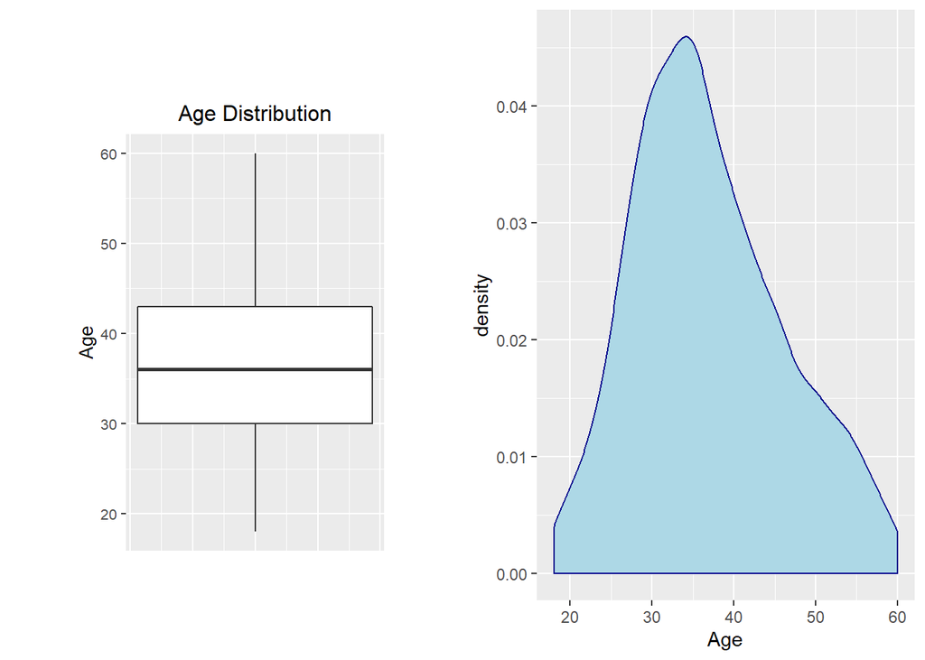

```r
grid.arrange(ggplot(data = df) +
  geom_boxplot(mapping = aes(x = 1,y = Age))+
  ggtitle('Age Distribution')+
  labs(x = '', y = 'Age')+
  theme(axis.title.x=element_blank(),
        axis.text.x=element_blank(),
        axis.ticks.x=element_blank(),#delete the x axis lables
        plot.title = element_text(hjust = 0.5),# title center
        text =  element_text(size=10),plot.margin = margin(2,1.5,2,1.5, "cm")),
  ggplot(df, aes(x=Age))+
  geom_density(color="darkblue", fill="lightblue"),
ncol=2)
```

```r
# grid.arrange(df %>% ggplot(mapping = aes(x = Age)) + geom_histogram(),
#              df %>% ggplot(mapping = aes(x = 1, y = Age)) + geom_boxplot() + coord_flip(),
#              ncol = 1)
```

Comments:

- No Outliers
- Confirms that the distribution is skewed and will use median instead of mean

### 4.1.2 MonthlyIncome

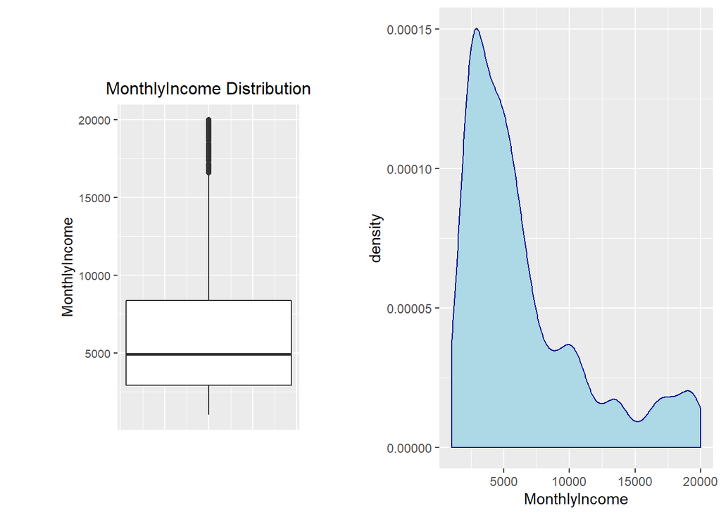

```r
grid.arrange(ggplot(data = df) +
  geom_boxplot(mapping = aes(x = 1,y = MonthlyIncome))+
  ggtitle('MonthlyIncome Distribution')+
  labs(x = '', y = 'MonthlyIncome')+
  theme(axis.title.x=element_blank(),
        axis.text.x=element_blank(),
        axis.ticks.x=element_blank(),#delete the x axis lables
        plot.title = element_text(hjust = 0.5),# title center
        text =  element_text(size=10),plot.margin = margin(2,1.5,2,1.5, "cm")),
  ggplot(df, aes(x=MonthlyIncome))+
  geom_density(color="darkblue", fill="lightblue"),
ncol=2)
```

Comments:

- Outliers above $15000
- Confirms that the distribution is skewed and will use median instead of mean

### 4.1.3 TotalWorkingYears

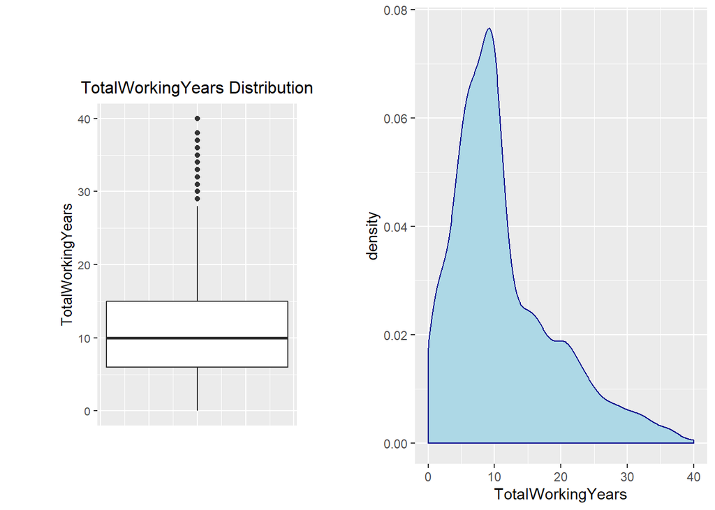

```r
grid.arrange(ggplot(data = df) +
  geom_boxplot(mapping = aes(x = 1,y = TotalWorkingYears))+
  ggtitle('TotalWorkingYears Distribution')+
  labs(x = '', y = 'TotalWorkingYears')+
  theme(axis.title.x=element_blank(),
        axis.text.x=element_blank(),
        axis.ticks.x=element_blank(),#delete the x axis lables
        plot.title = element_text(hjust = 0.5),# title center
        text =  element_text(size=10),plot.margin = margin(2,1.5,2,1.5, "cm")),
  ggplot(df, aes(x=TotalWorkingYears))+
  geom_density(color="darkblue", fill="lightblue"),
ncol=2)
```

Comments:

- Outliers above 28 years
- Confirms that the distribution is skewed and will use median instead of mean

### 4.1.4 YearsAtCompany

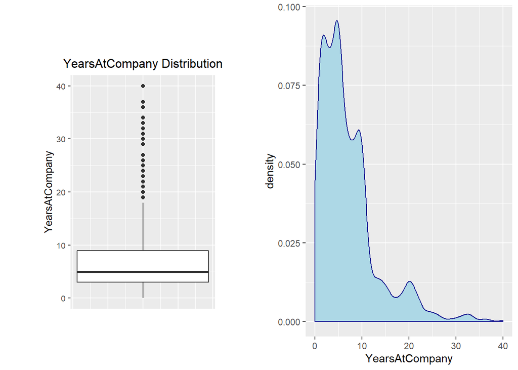

```r
grid.arrange(ggplot(data = df) +
  geom_boxplot(mapping = aes(x = 1,y = YearsAtCompany))+
  ggtitle('YearsAtCompany Distribution')+
  labs(x = '', y = 'YearsAtCompany')+
  theme(axis.title.x=element_blank(),
        axis.text.x=element_blank(),
        axis.ticks.x=element_blank(),#delete the x axis lables
        plot.title = element_text(hjust = 0.5),# title center
        text =  element_text(size=10),plot.margin = margin(2,1.5,2,1.5, "cm")),
  ggplot(df, aes(x=YearsAtCompany))+
  geom_density(color="darkblue", fill="lightblue"),
ncol=2)
```

Comments:

- Outliers above 19 years
- Confirms that the distribution is skewed and will use median instead of mean

### 4.1.5 YearsInCurrentRole

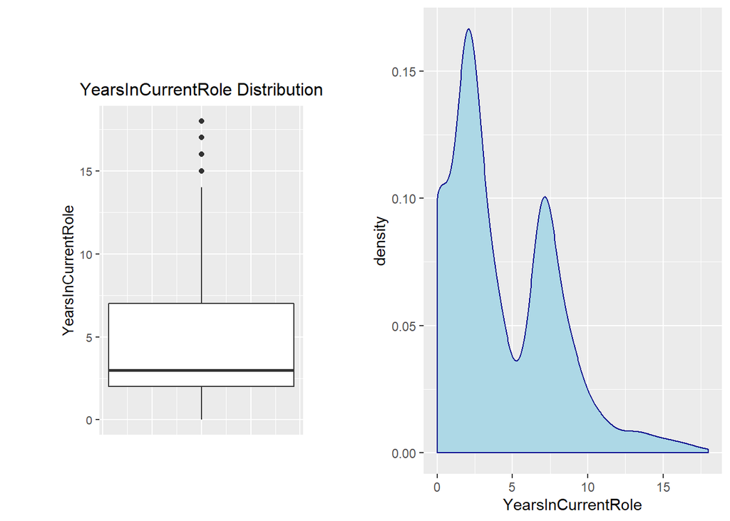

```r
grid.arrange(ggplot(data = df) +
  geom_boxplot(mapping = aes(x = 1,y = YearsInCurrentRole))+
  ggtitle('YearsInCurrentRole Distribution')+
  labs(x = '', y = 'YearsInCurrentRole')+
  theme(axis.title.x=element_blank(),
        axis.text.x=element_blank(),
        axis.ticks.x=element_blank(),#delete the x axis lables
        plot.title = element_text(hjust = 0.5),# title center
        text =  element_text(size=10),plot.margin = margin(2,1.5,2,1.5, "cm")),
  ggplot(df, aes(x=YearsInCurrentRole))+
  geom_density(color="darkblue", fill="lightblue"),
ncol=2)
```

Comments:

- Outliers above 15 years
- Distribution is bi-model both distributions have roughly the same mean and median, so we will use mean

### 4.1.6 YearsSinceLastPromotion

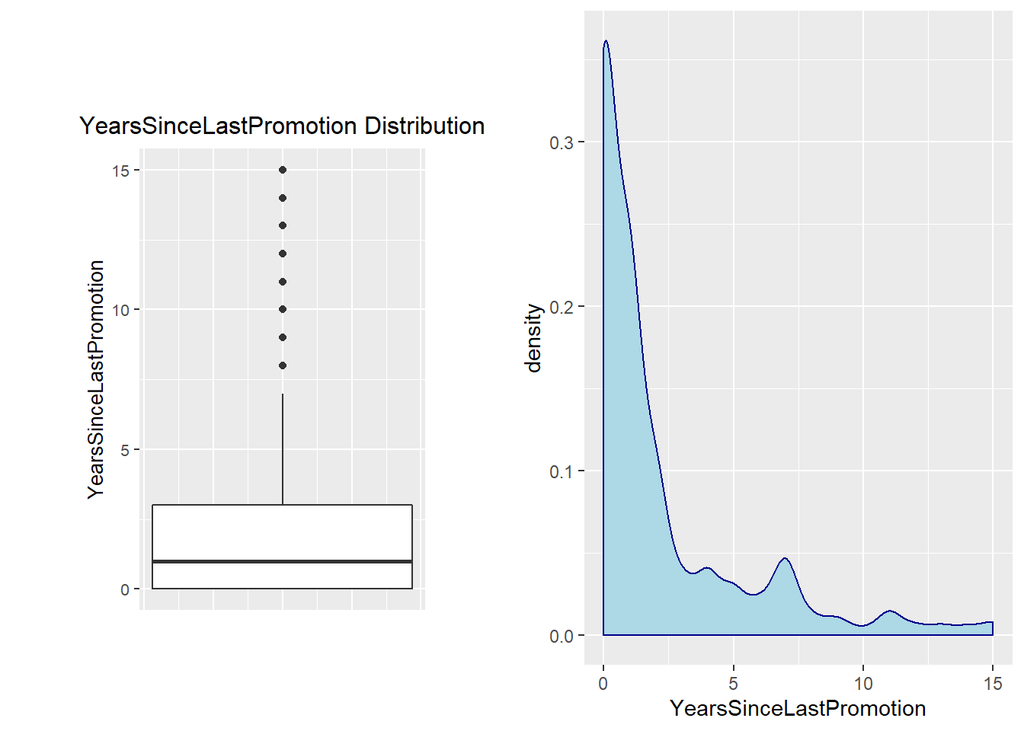

```r
grid.arrange(ggplot(data = df) +
  geom_boxplot(mapping = aes(x = 1,y = YearsSinceLastPromotion))+
  ggtitle('YearsSinceLastPromotion Distribution')+
  labs(x = '', y = 'YearsSinceLastPromotion')+
  theme(axis.title.x=element_blank(),
        axis.text.x=element_blank(),
        axis.ticks.x=element_blank(),#delete the x axis lables
        plot.title = element_text(hjust = 0.5),# title center
        text =  element_text(size=10),plot.margin = margin(2,1.5,2,1.5, "cm")),
  ggplot(df, aes(x=YearsSinceLastPromotion))+
  geom_density(color="darkblue", fill="lightblue"),
ncol=2)
```

Comments:

- Outliers above 7 years
- Confirms that the distribution is skewed and will use median instead of mean

### 4.1.7 YearsWithCurrManager

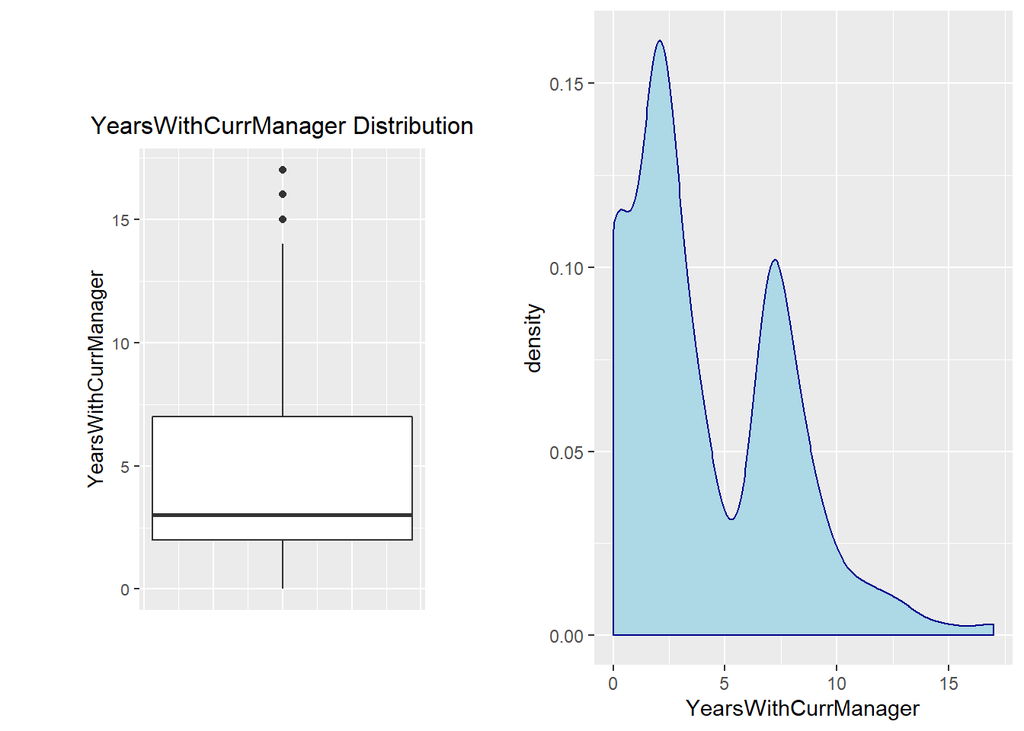

```r
grid.arrange(ggplot(data = df) +
  geom_boxplot(mapping = aes(x = 1,y = YearsWithCurrManager))+
  ggtitle('YearsWithCurrManager Distribution')+
  labs(x = '', y = 'YearsWithCurrManager')+
  theme(axis.title.x=element_blank(),
        axis.text.x=element_blank(),
        axis.ticks.x=element_blank(),#delete the x axis lables
        plot.title = element_text(hjust = 0.5),# title center
        text =  element_text(size=10),plot.margin = margin(2,1.5,2,1.5, "cm")),
  ggplot(df, aes(x=YearsWithCurrManager))+
  geom_density(color="darkblue", fill="lightblue"),
ncol=2)
```

Comments:

- Outliers above 15 years
- Distribution is bi-model both distributions have roughly the same mean and median, so we will use mean

## 4.2 Categorical variable

### 4.2.1 Job Level

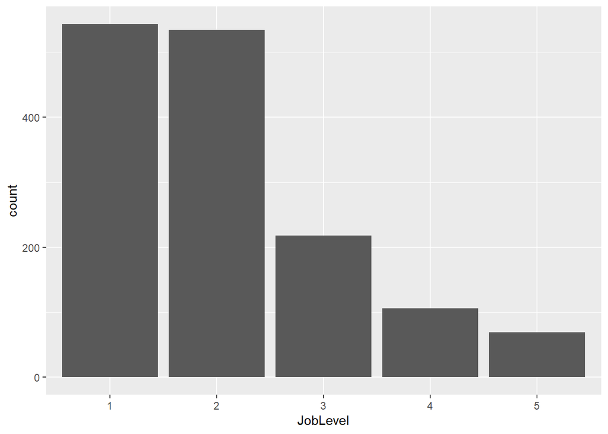

```r
df %>% ggplot(mapping = aes(x = JobLevel)) + geom_bar()
```

Most jobs are associated with level 1 and 2

### 4.2.2 Attrition

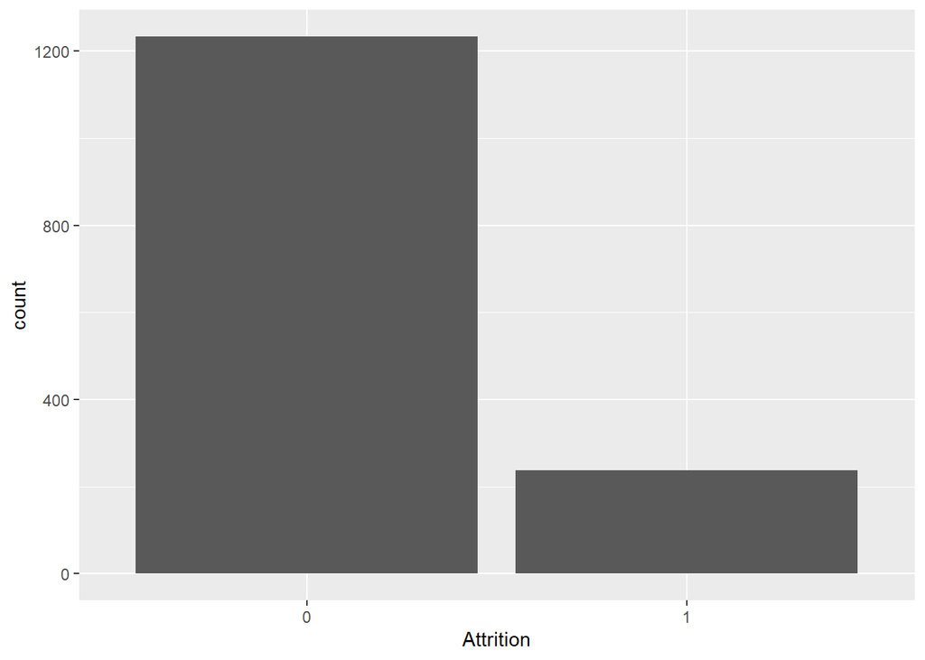

```r
df %>% ggplot(mapping = aes(x = Attrition)) + geom_bar()
```

### 4.2.3 EnvironmentSatisfaction

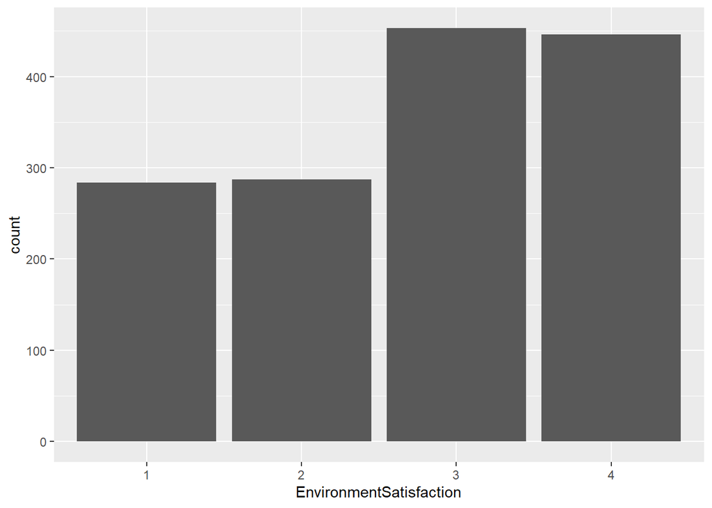

```r
df %>% ggplot(mapping = aes(x = EnvironmentSatisfaction)) + geom_bar()
```

Most Employee are satisfied with their working environment

### 4.2.4 JobSatisfaction

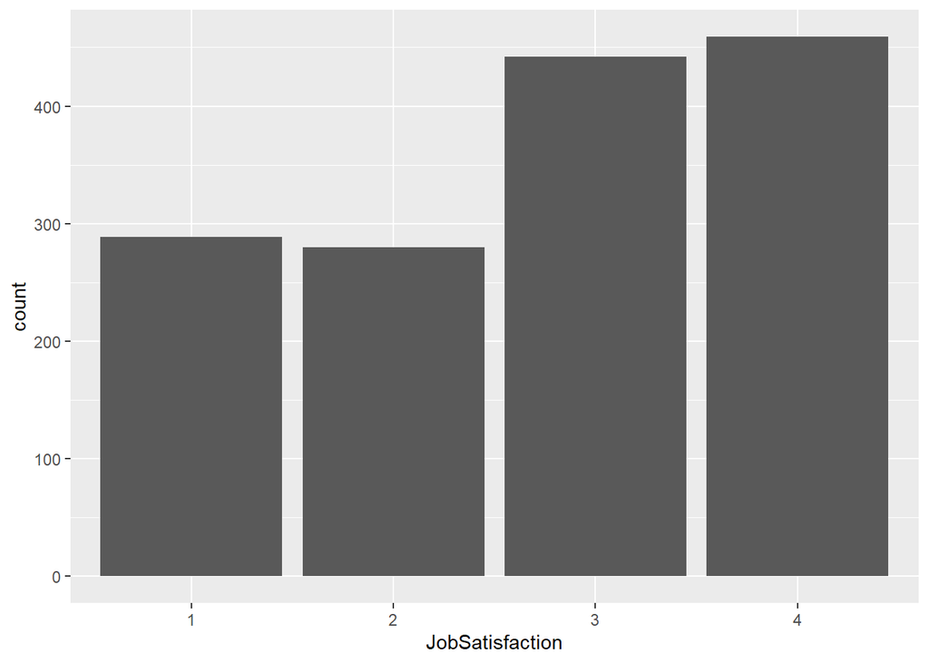

```r
df %>% ggplot(mapping = aes(x = JobSatisfaction)) + geom_bar()
```

Most employees are satisfied with their job enviroment

### 4.2.5 Training

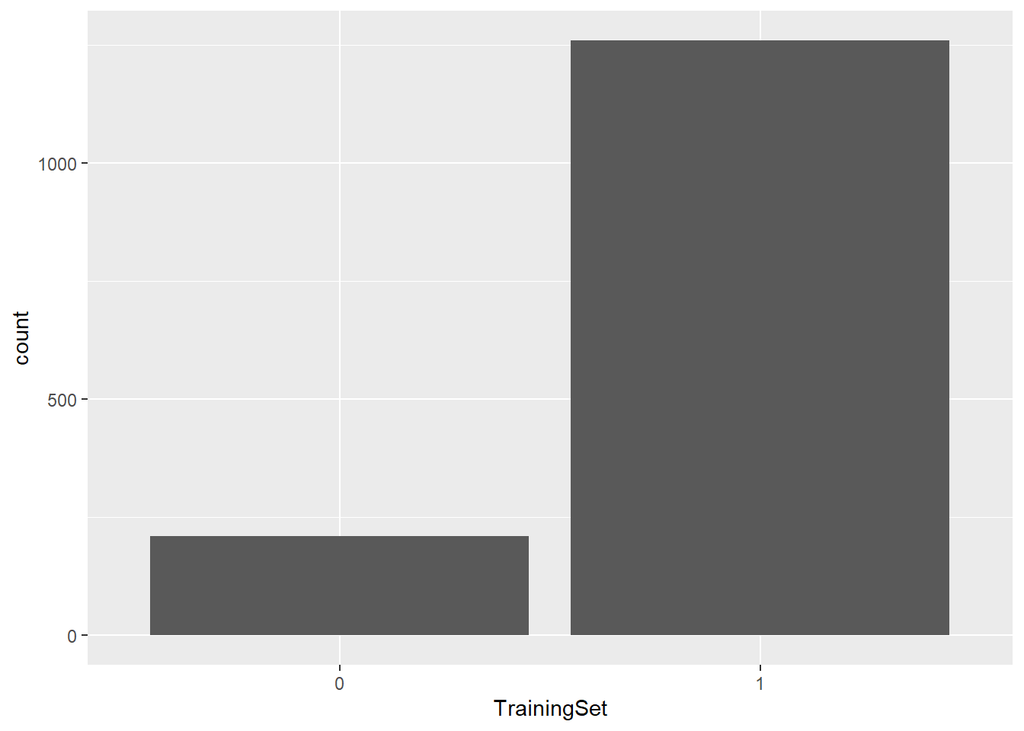

```r
df %>% ggplot(mapping = aes(x = TrainingSet)) + geom_bar()
```

Most employees have been trained.

### 4.2.6 JobRole

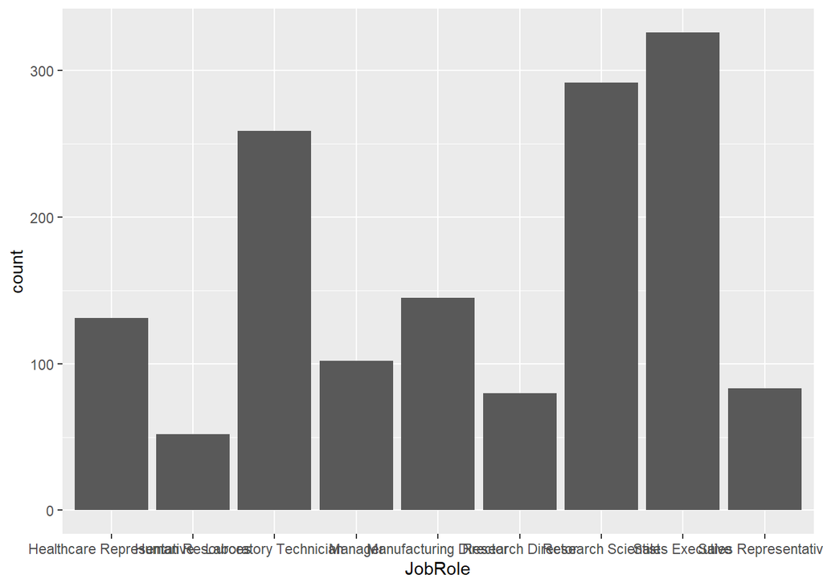

```r
df %>% ggplot(mapping = aes(x = JobRole)) + geom_bar()
```

Questions: 1.So many employees have high satisfaction with job and environment, then why are so many being trained? 2. How does training affect promotion? 3.Does Training make employess more satisfied with their environment and job? 4. Do employees being trained have higher median monthly income? 5.How long do they spend in their current role and maanger before being put into training?

# 5 Base EDA Step 3: Multivariate non-graphical

## 5.1 Categorical

### 5.1.1 Job Role with Job level

```r
df %>%
  tabyl(JobRole, JobLevel) %>%
  adorn_totals(where = c("row", "col")) %>%
  adorn_percentages("row") %>%
  adorn_pct_formatting()%>%
  adorn_ns()
```

```
##                    JobRole           1           2           3           4
##  Healthcare Representative  0.0%   (0) 59.5%  (78) 33.6%  (44)  6.9%   (9)
##            Human Resources 63.5%  (33) 25.0%  (13) 11.5%   (6)  0.0%   (0)
##      Laboratory Technician 77.2% (200) 21.6%  (56)  1.2%   (3)  0.0%   (0)
##                    Manager  0.0%   (0)  0.0%   (0) 11.8%  (12) 46.1%  (47)
##     Manufacturing Director  0.0%   (0) 62.1%  (90) 31.0%  (45)  6.9%  (10)
##          Research Director  0.0%   (0)  0.0%   (0) 35.0%  (28) 32.5%  (26)
##         Research Scientist 80.1% (234) 19.5%  (57)  0.3%   (1)  0.0%   (0)
##            Sales Executive  0.0%   (0) 71.5% (233) 24.2%  (79)  4.3%  (14)
##       Sales Representative 91.6%  (76)  8.4%   (7)  0.0%   (0)  0.0%   (0)
##                      Total 36.9% (543) 36.3% (534) 14.8% (218)  7.2% (106)
##           5         Total
##   0.0%  (0) 100.0%  (131)
##   0.0%  (0) 100.0%   (52)
##   0.0%  (0) 100.0%  (259)
##  42.2% (43) 100.0%  (102)
##   0.0%  (0) 100.0%  (145)
##  32.5% (26) 100.0%   (80)
##   0.0%  (0) 100.0%  (292)
##   0.0%  (0) 100.0%  (326)
##   0.0%  (0) 100.0%   (83)
##   4.7% (69) 100.0% (1470)
```

Level 1 consists of Human rEources, Laboratory Technicians, Research Scientist and Sale Representative Level 2 consists of Mostly Healthcare Representatives, Manufacturing director and Sales Executive Level 3 consists ofhealthcare representatives,human resources, manager, manufacturing director, research director and sales executives level 4 consists of mostly managers and research directors level 5 consists of managers and research directors

### 5.1.2 Attrition with Job level

```r
df %>%
  tabyl(Attrition, JobLevel) %>%
  adorn_totals(where = c("row", "col")) %>%
  adorn_percentages("row") %>%
  adorn_pct_formatting()%>%
  adorn_ns()
```

```
##  Attrition           1           2           3          4         5
##          0 32.4% (400) 39.1% (482) 15.1% (186) 8.2% (101) 5.2% (64)
##          1 60.3% (143) 21.9%  (52) 13.5%  (32) 2.1%   (5) 2.1%  (5)
##      Total 36.9% (543) 36.3% (534) 14.8% (218) 7.2% (106) 4.7% (69)
##          Total
##  100.0% (1233)
##  100.0%  (237)
##  100.0% (1470)
```

### 5.1.3 Atrrition with Training received in the last Year

```r
#df$TrainingSet <- ifelse(levels(df$TrainingTimesLastYear)==0,"0","1")
 #df$Training <- ifelse(levels(df$TrainingTimesLastYear)==0,"No","Yes")
df %>%
  tabyl( Training,Attrition) %>%
  adorn_totals(where = c("row", "col")) %>%
  adorn_percentages("col") %>%
  adorn_pct_formatting()%>%
  adorn_ns()
```

```
##  Training             0            1         Total
##        No  13.9%  (172)  16.0%  (38)  14.3%  (210)
##       Yes  86.1% (1061)  84.0% (199)  85.7% (1260)
##     Total 100.0% (1233) 100.0% (237) 100.0% (1470)
```

### 5.1.4 Attrition vs Training vs JobSatisfaction

```r
df %>%
  tabyl( JobSatisfaction,Training,Attrition) %>%
  adorn_totals(where = c("row", "col")) %>%
  adorn_percentages("col") %>%
  adorn_pct_formatting()%>%
  adorn_ns()
```

```
## $`0`
##  JobSatisfaction           No           Yes         Total
##                1  20.9%  (36)  17.6%  (187)  18.1%  (223)
##                2  14.5%  (25)  19.7%  (209)  19.0%  (234)
##                3  32.6%  (56)  29.5%  (313)  29.9%  (369)
##                4  32.0%  (55)  33.2%  (352)  33.0%  (407)
##            Total 100.0% (172) 100.0% (1061) 100.0% (1233)
##
## $`1`
##  JobSatisfaction          No          Yes        Total
##                1  26.3% (10)  28.1%  (56)  27.8%  (66)
##                2  21.1%  (8)  19.1%  (38)  19.4%  (46)
##                3  21.1%  (8)  32.7%  (65)  30.8%  (73)
##                4  31.6% (12)  20.1%  (40)  21.9%  (52)
##            Total 100.0% (38) 100.0% (199) 100.0% (237)
```

Employees who are trained and leave, are less satisfied with their job.

### 5.1.5 Attrition vs Training vs EnvironmentSatisfaction

```r
df %>%
  tabyl( EnvironmentSatisfaction,Training,Attrition) %>%
  adorn_totals(where = c("row", "col")) %>%
  adorn_percentages("col") %>%
  adorn_pct_formatting()%>%
  adorn_ns()
```

```
## $`0`
##  EnvironmentSatisfaction           No           Yes         Total
##                        1  14.5%  (25)  17.6%  (187)  17.2%  (212)
##                        2  16.9%  (29)  20.3%  (215)  19.8%  (244)
##                        3  29.7%  (51)  32.0%  (340)  31.7%  (391)
##                        4  39.0%  (67)  30.1%  (319)  31.3%  (386)
##                    Total 100.0% (172) 100.0% (1061) 100.0% (1233)
##
## $`1`
##  EnvironmentSatisfaction          No          Yes        Total
##                        1  28.9% (11)  30.7%  (61)  30.4%  (72)
##                        2  13.2%  (5)  19.1%  (38)  18.1%  (43)
##                        3  31.6% (12)  25.1%  (50)  26.2%  (62)
##                        4  26.3% (10)  25.1%  (50)  25.3%  (60)
##                    Total 100.0% (38) 100.0% (199) 100.0% (237)
```

Employees who are trained and leave, are less satisfied with their environment.

## 5.2 Quatitative

```r
df_num$TrainingSet <- ifelse(df_num$TrainingTimesLastYear==0,0,1)
df_num %>% select(Attrition,Age,TotalWorkingYears,TrainingSet, MonthlyIncome, YearsSinceLastPromotion, YearsInCurrentRole,YearsAtCompany,YearsWithCurrManager) %>% cor()
```

```
##                           Attrition           Age TotalWorkingYears
## Attrition                1.00000000 -0.1592050069      -0.171063246
## Age                     -0.15920501  1.0000000000       0.680380536
## TotalWorkingYears       -0.17106325  0.6803805358       1.000000000
## TrainingSet             -0.06189441  0.0003507411       0.008414448
## MonthlyIncome           -0.15983958  0.4978545669       0.772893246
## YearsSinceLastPromotion -0.03301878  0.2165133679       0.404857759
## YearsInCurrentRole      -0.16054500  0.2129010556       0.460364638
## YearsAtCompany          -0.13439221  0.3113087697       0.628133155
## YearsWithCurrManager    -0.15619932  0.2020886024       0.459188397
##                           TrainingSet MonthlyIncome
## Attrition               -0.0618944070   -0.15983958
## Age                      0.0003507411    0.49785457
## TotalWorkingYears        0.0084144481    0.77289325
## TrainingSet              1.0000000000    0.01199263
## MonthlyIncome            0.0119926260    1.00000000
## YearsSinceLastPromotion -0.0099478556    0.34497764
## YearsInCurrentRole       0.0033744170    0.36381767
## YearsAtCompany           0.0386414799    0.51428483
## YearsWithCurrManager     0.0300599048    0.34407888
##                         YearsSinceLastPromotion YearsInCurrentRole
## Attrition                          -0.033018775       -0.160545004
## Age                                 0.216513368        0.212901056
## TotalWorkingYears                   0.404857759        0.460364638
## TrainingSet                        -0.009947856        0.003374417
## MonthlyIncome                       0.344977638        0.363817667
## YearsSinceLastPromotion             1.000000000        0.548056248
## YearsInCurrentRole                  0.548056248        1.000000000
## YearsAtCompany                      0.618408865        0.758753737
## YearsWithCurrManager                0.510223636        0.714364762
##                         YearsAtCompany YearsWithCurrManager
## Attrition                  -0.13439221           -0.1561993
## Age                         0.31130877            0.2020886
## TotalWorkingYears           0.62813316            0.4591884
## TrainingSet                 0.03864148            0.0300599
## MonthlyIncome               0.51428483            0.3440789
## YearsSinceLastPromotion     0.61840887            0.5102236
## YearsInCurrentRole          0.75875374            0.7143648
## YearsAtCompany              1.00000000            0.7692124
## YearsWithCurrManager        0.76921243            1.0000000
```

Findings:

Questions:

- If employees are trained, is there a decrease in monthly income,making them unhappy and hence leaving?
- If the employees are trained, and takes longer time to be promoted,making them unhappy and hence leaving?
- If the employees are trained, and spend longer/lesser in their current position,making them unhappy and hence leaving?
- If the employees are trained, and spend longer/lesser time with their manager, making them unhappy and hence leaving?
- Are younger or older people receiving more training?

## 5.3 Quatitative and Categorical

```r
monthly_incr <- df %>%
  group_by(Training,JobLevel) %>%
  summarise(med_inc = median(YearsAtCompany)) %>%
  select(Training,JobLevel, (med_inc)) %>%
  spread(key = Training, value = med_inc) %>%
  mutate(Training0vs1 = (Yes-No))

monthly_incr
```

```
## # A tibble: 5 x 4
##   JobLevel    No   Yes Training0vs1
##   <fct>    <dbl> <dbl>        <dbl>
## 1 1            4   3           -1
## 2 2            7   6           -1
## 3 3           10   9           -1
## 4 4            8  14            6
## 5 5            4  19.5         15.5
```

```r
df_monthly_incr <- df %>%
  group_by(Training,Attrition) %>%
  summarise(med_inc = median(MonthlyIncome)) %>%
  select(Training,Attrition, (med_inc)) %>%
  spread(key = Training, value = med_inc) %>%
  mutate(Training0vs1 = (Yes-No)/No*100)

df_monthly_incr
```

```
## # A tibble: 2 x 4
##   Attrition    No   Yes Training0vs1
##   <fct>     <dbl> <dbl>        <dbl>
## 1 0         5008.  5210         4.04
## 2 1         3903   3102       -20.5
```

The monthly income decreases by 20.5% with training than no training for employees that were turned over. The monthly income increases by 4.04% with training than no training employees that were retained.

```r
df_yearsatcompany <- df %>%
  group_by(Training,JobLevel) %>%
  summarise(med_inc = median(YearsAtCompany)) %>%
  select(Training,JobLevel, (med_inc)) %>%
  spread(key = Training, value = med_inc) %>%
  mutate(Training0vs1 = (Yes-No)/No*100)
df_yearsatcompany
```

```
## # A tibble: 5 x 4
##   JobLevel    No   Yes Training0vs1
##   <fct>    <dbl> <dbl>        <dbl>
## 1 1            4   3          -25
## 2 2            7   6          -14.3
## 3 3           10   9          -10
## 4 4            8  14           75
## 5 5            4  19.5        388.
```

For job levels 1-3 with training , the median years in the company tend to be lower by between 10-25%. For job level 4 and 5, the median years in the company tend to increase with training.

```r
df_yearsatcurrentrole <- df %>%
  group_by(Training,JobLevel) %>%
  summarise(med_inc = median(YearsInCurrentRole)) %>%
  select(Training,JobLevel, (med_inc)) %>%
  spread(key = Training, value = med_inc) %>%
  mutate(Training0vs1 = (Yes-No)/No*100)
df_yearsatcurrentrole
```

```
## # A tibble: 5 x 4
##   JobLevel    No   Yes Training0vs1
##   <fct>    <dbl> <dbl>        <dbl>
## 1 1            2     2          0
## 2 2            4     3        -25
## 3 3            8     7        -12.5
## 4 4            6     7         16.7
## 5 5            2     7        250
```

For job levels 2-3 with training , the median years in the current role tend to be lower by between 10-25%. For job level 1, there is no difference with or without training for the years spent in the current role. For job level 4 and 5, the median years in the current role tend to increase with training.

```r
df_yearswithcurrmanager <- df %>%
  group_by(Training,JobLevel) %>%
  summarise(med_inc = median(YearsWithCurrManager)) %>%
  select(Training,JobLevel, (med_inc)) %>%
  spread(key = Training, value = med_inc) %>%
  mutate(Training0vs1 = (Yes-No)/No*100)
df_yearswithcurrmanager
```

```
## # A tibble: 5 x 4
##   JobLevel    No   Yes Training0vs1
##   <fct>    <dbl> <dbl>        <dbl>
## 1 1          2       2          0
## 2 2          4       3        -25
## 3 3          7       7          0
## 4 4          5.5     7         27.3
## 5 5          2       7        250
```

For job levels2 with training , the median years with the manager tend to be lower by between 25%. For job level 1 and 3, there is no difference with or without training for the years spent with the manager. For job level 4 and 5, the median years with the manager tend to increase with training.

```r
df_yearsSincelastpromo <- df %>%
  group_by(Training,JobLevel) %>%
  summarise(med_inc = median(YearsSinceLastPromotion)) %>%
  select(Training,JobLevel, (med_inc)) %>%
  spread(key = Training, value = med_inc) %>%
  mutate(Training0vs1 = (Yes-No)/No*100)
df_yearsSincelastpromo
```

```
## # A tibble: 5 x 4
##   JobLevel    No   Yes Training0vs1
##   <fct>    <dbl> <dbl>        <dbl>
## 1 1          1       1            0
## 2 2          1       1            0
## 3 3          4       1          -75
## 4 4          2.5     3           20
## 5 5          2       2            0
```

For job level 1,2 and 5, there is no difference with or without training for the years since last promotion. For job levels 3 with training , the median years since last promotion tend to be lower by between 75%. For job levels 4 with training , the median years since last promotion tend to be higher by between 20%.

```r
df_age <- df %>%
  group_by(Training,JobLevel) %>%
  summarise(med_inc = median(Age)) %>%
  select(Training,JobLevel, (med_inc)) %>%
  spread(key = Training, value = med_inc) %>%
  mutate(Training0vs1 = (Yes-No)/No*100)
df_age
```

```
## # A tibble: 5 x 4
##   JobLevel    No   Yes Training0vs1
##   <fct>    <dbl> <dbl>        <dbl>
## 1 1           32  31          -3.12
## 2 2           35  36           2.86
## 3 3           41  38          -7.32
## 4 4           50  47.5        -5
## 5 5           47  48           2.13
```

Younger people tend to receive more training in job level 1,3 and 4.

```r
df_ttworkingyrs <- df %>%
  group_by(Training,JobLevel) %>%
  summarise(med_inc = median(TotalWorkingYears)) %>%
  select(Training,JobLevel, (med_inc)) %>%
  spread(key = Training, value = med_inc) %>%
  mutate(Training0vs1 = (Yes-No)/No*100)
df_ttworkingyrs
```

```
## # A tibble: 5 x 4
##   JobLevel    No   Yes Training0vs1
##   <fct>    <dbl> <dbl>        <dbl>
## 1 1            6     6         0
## 2 2           10    10         0
## 3 3           16    13       -18.8
## 4 4           24    25         4.17
## 5 5           24    25         4.17
```

Job level three with training tend to give lower total working years in the company.

# 6 Base EDA Step 4: Multi-variate graphical analysis

## 6.1 Categorical

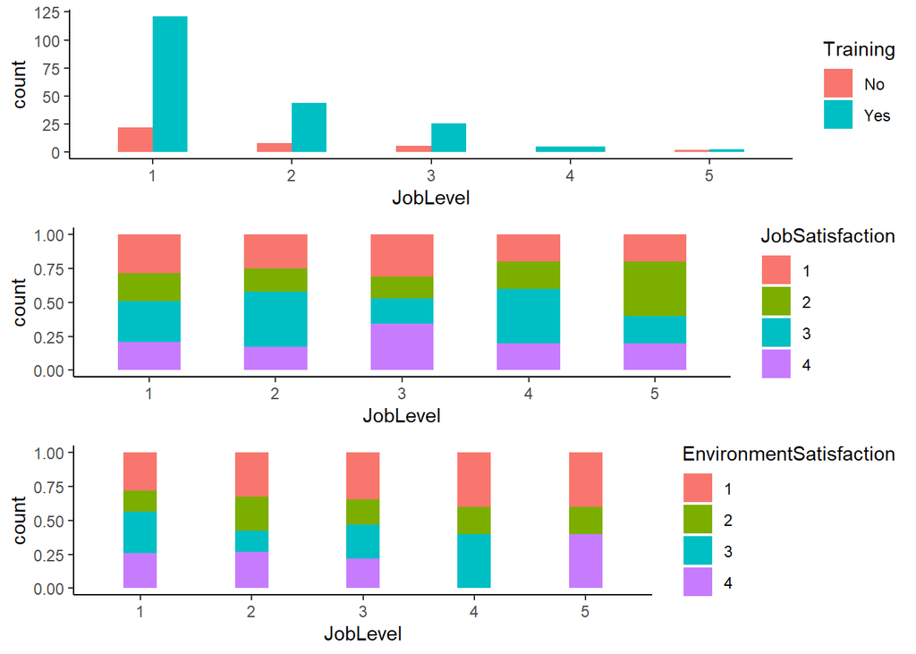

```r
df_JL <- df %>%
  filter(Attrition==1)

# Job level 1  across Training,attrition

grid.arrange(
  df_JL %>%
    ggplot(mapping = aes(x = JobLevel, fill = Training)) +
    geom_bar(position = "dodge", width = 0.5) +
    theme_classic(),

# job level 1 job satisfaction and environment
 df_JL %>%
    ggplot(mapping = aes(x = JobLevel, fill = JobSatisfaction)) +
    geom_bar(position = "fill", width = 0.5) +
    theme_classic(),

  df_JL %>%
    ggplot(mapping = aes(x = JobLevel, fill = EnvironmentSatisfaction)) +
    geom_bar(position = "fill", width = 0.3) +
    theme_classic(),
 ncol=1)
```

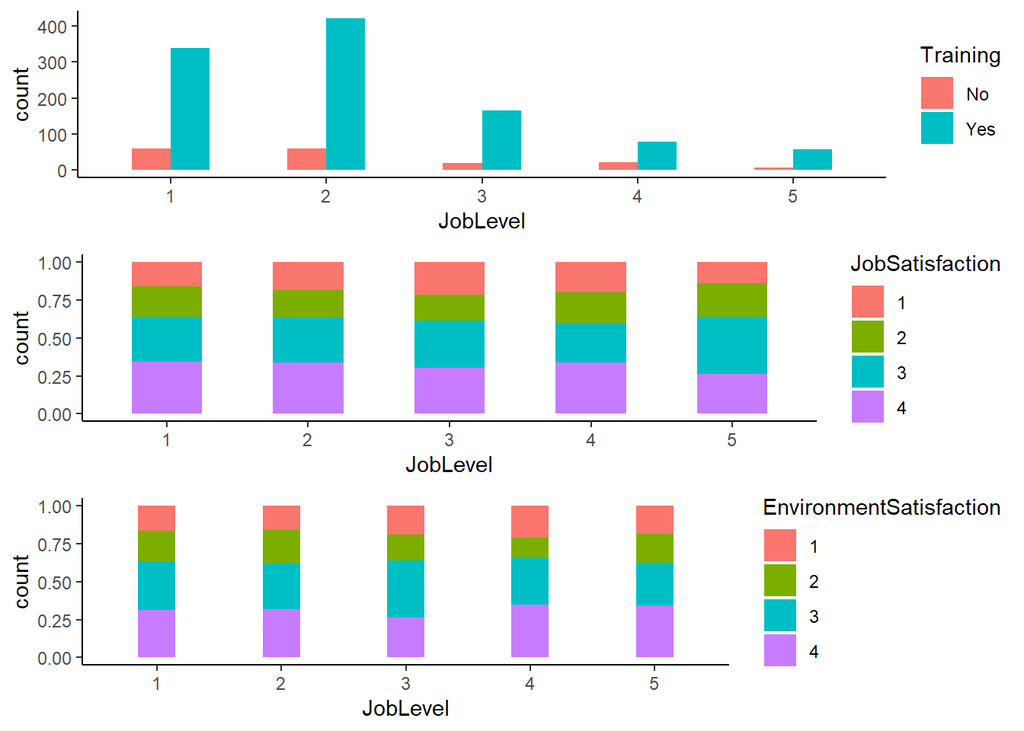

```r
df_JL <- df %>%
  filter(Attrition==0)

# Job level 1  across Training,attrition

grid.arrange(
  df_JL %>%
    ggplot(mapping = aes(x = JobLevel, fill = Training)) +
    geom_bar(position = "dodge", width = 0.5) +
    theme_classic(),

# job level 1 job satisfaction and environment
 df_JL %>%
    ggplot(mapping = aes(x = JobLevel, fill = JobSatisfaction)) +
    geom_bar(position = "fill", width = 0.5) +
    theme_classic(),

  df_JL %>%
    ggplot(mapping = aes(x = JobLevel, fill = EnvironmentSatisfaction)) +
    geom_bar(position = "fill", width = 0.3) +
    theme_classic(),
 ncol=1)
```

From the two graphs, we can definitely confirm that employees who leave the company are far more dissatisfied with the job and environment than employees who stay.

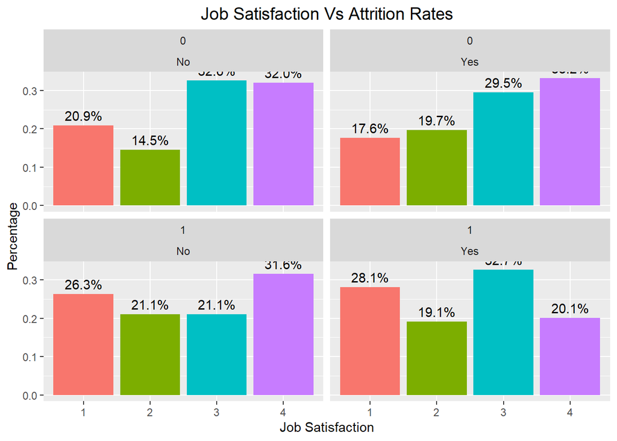

```r
ggplot(df,aes(x=JobSatisfaction,group=Attrition,Training))+geom_bar(stat="count",aes(y=..prop..,fill=factor(..x..)))+labs(x="Job Satisfaction",y="Percentage",title="Job Satisfaction Vs Attrition Rates")+facet_wrap(~Attrition+Training)+theme(legend.position="none",plot.title=element_text(hjust=0.5,size=14))+geom_text(aes(label=scales::percent(..prop..),y=..prop..),stat="count",vjust=-0.5)
```

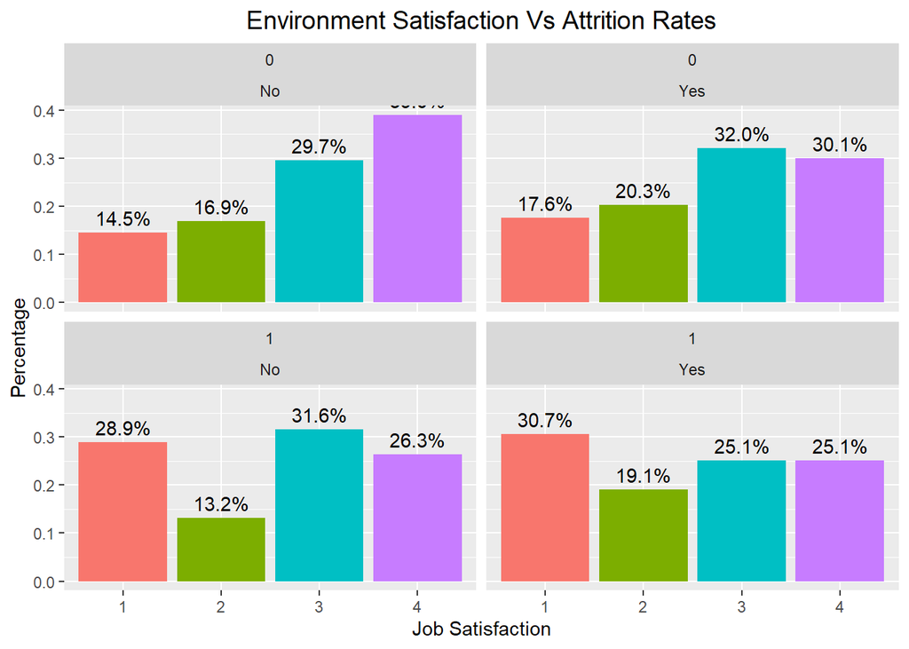

```r
ggplot(df,aes(x=EnvironmentSatisfaction,group=Attrition,Training))+geom_bar(stat="count",aes(y=..prop..,fill=factor(..x..)))+labs(x="Job Satisfaction",y="Percentage",title="Environment Satisfaction Vs Attrition Rates")+facet_wrap(~Attrition+Training)+theme(legend.position="none",plot.title=element_text(hjust=0.5,size=14))+geom_text(aes(label=scales::percent(..prop..),y=..prop..),stat="count",vjust=-0.5)
```

All Employees who are being training become less satisfied with the environment.

## 6.2 Quantitative

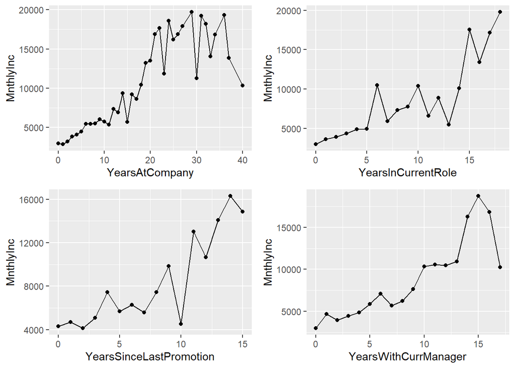

```r
grid.arrange(
df%>%group_by(YearsAtCompany) %>%
             summarise(MnthlyInc = median(MonthlyIncome, na.rm = TRUE))%>%
  ggplot(aes(x = YearsAtCompany, y = MnthlyInc)) +
  geom_point() + geom_line(),
df%>%group_by(YearsInCurrentRole) %>%
             summarise(MnthlyInc = median(MonthlyIncome, na.rm = TRUE))%>%
  ggplot(aes(x = YearsInCurrentRole, y = MnthlyInc)) +
  geom_point() + geom_line(),
df%>%group_by(YearsSinceLastPromotion) %>%
             summarise(MnthlyInc = median(MonthlyIncome, na.rm = TRUE))%>%
  ggplot(aes(x = YearsSinceLastPromotion, y = MnthlyInc)) +
  geom_point() + geom_line(),
df%>%group_by(YearsWithCurrManager) %>%
             summarise(MnthlyInc = median(MonthlyIncome, na.rm = TRUE))%>%
  ggplot(aes(x = YearsWithCurrManager, y = MnthlyInc)) +
  geom_point() + geom_line()



)
```

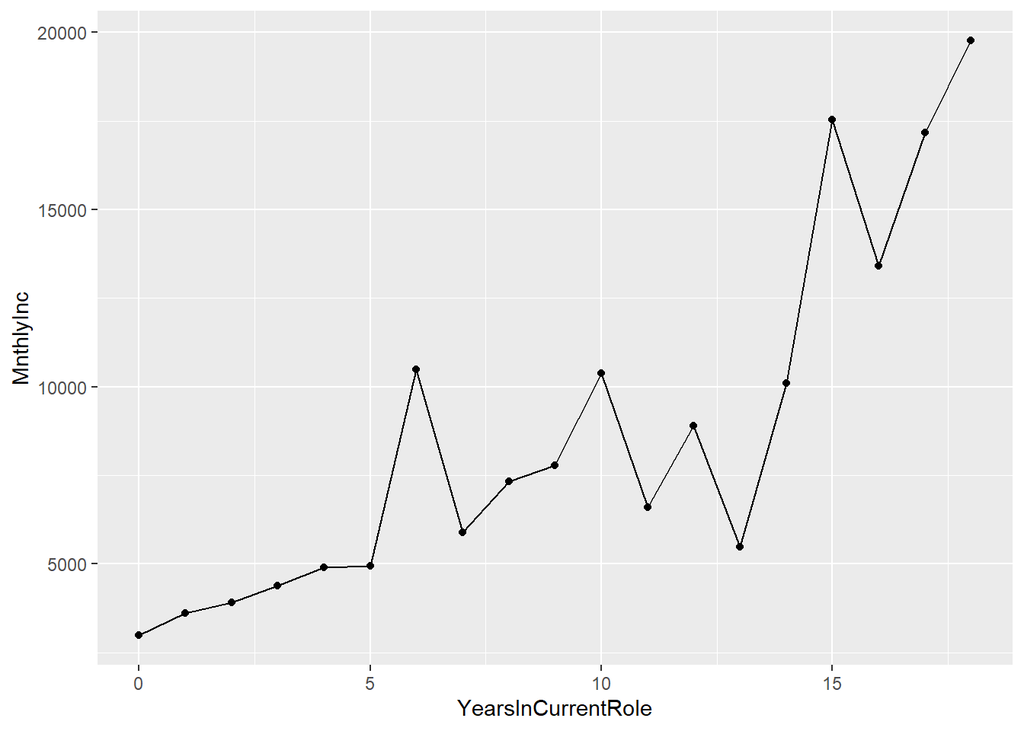

```r
df%>%group_by(YearsInCurrentRole) %>%
             summarise(MnthlyInc = median(MonthlyIncome, na.rm = TRUE))%>%
  ggplot(aes(x = YearsInCurrentRole, y = MnthlyInc)) +
  geom_point() + geom_line()
```

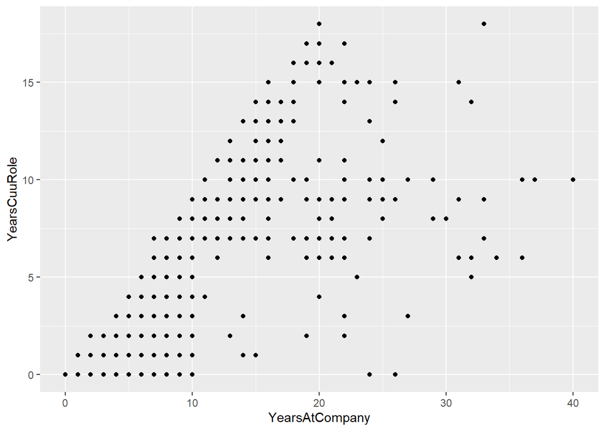

```r
df%>%group_by(YearsInCurrentRole,YearsAtCompany) %>%
             summarise(YearsCuuRole = median(YearsInCurrentRole, na.rm = TRUE))%>%
  ggplot(aes(x = YearsAtCompany, y = YearsCuuRole)) +
  geom_point()
```

There is a linear positive relationship with years at company with current role up till 20 years, but then there is not a linear relationship.This means after 20 years staying in the company,there are employees who switch their positions.

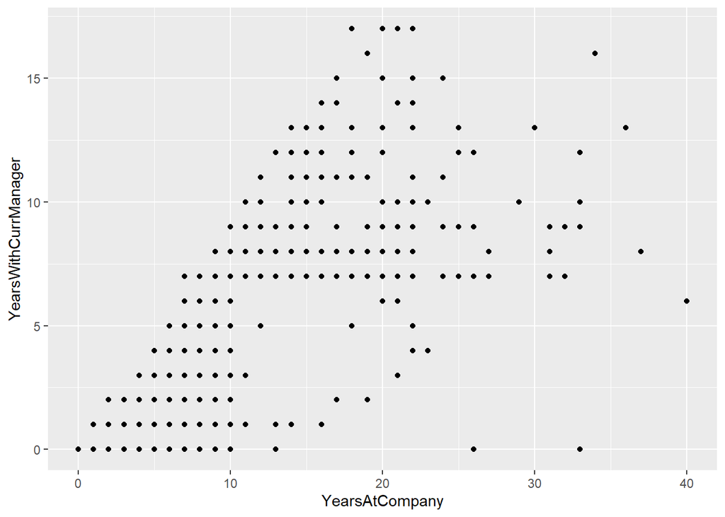

```r
df %>%
  ggplot(mapping = aes(x = YearsAtCompany, y = YearsWithCurrManager)) +
  geom_point()
```

There is a linear positive relationship with years at company with current manager up till 20 years, but then there is not a linear relationship.This means after 20 years staying in the company,there are employees who switch their managers.

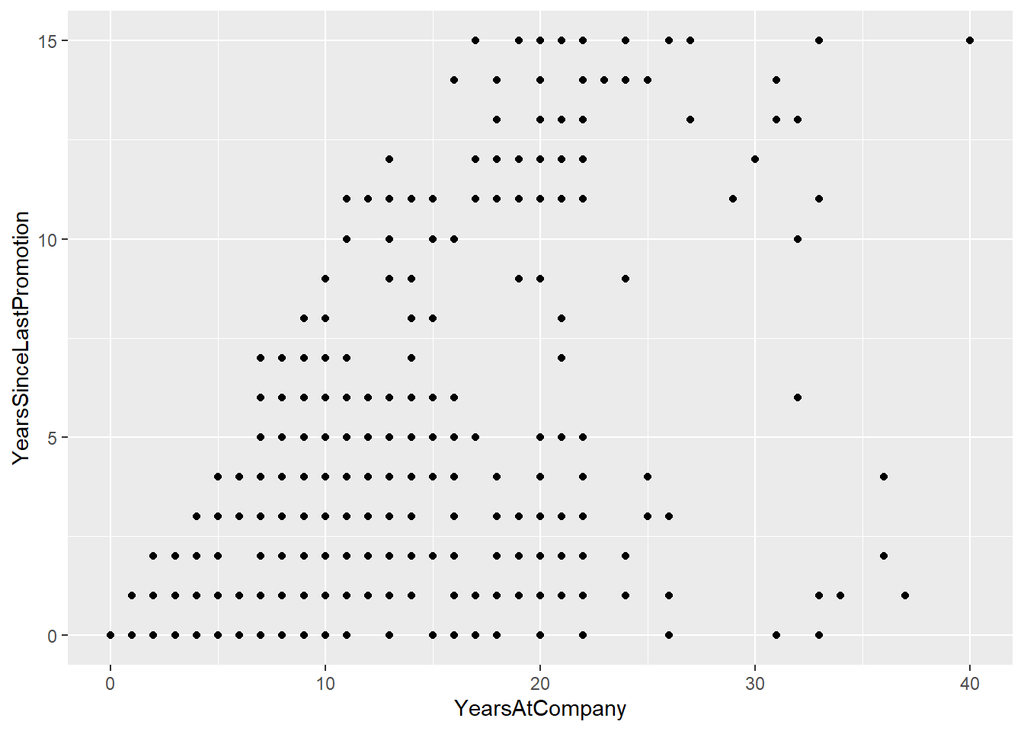

```r
df %>%
  ggplot(mapping = aes(x = YearsAtCompany, y = YearsSinceLastPromotion)) +
  geom_point()
```

There is somewhat positive linear relationship, but weak. Not all employees who have been working for the company for a long time receive more promotions.

## 6.3 Quantitative and Categorical

### 6.3.1 Median Monthly Income per Job Level with training for Attrition

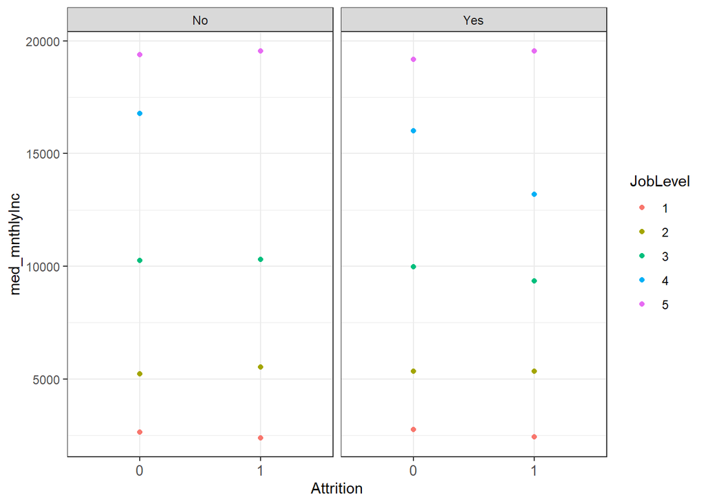

```r
df %>%
  group_by(JobLevel, Attrition, Training) %>%
  summarise(med_mnthlyInc = median(MonthlyIncome)) %>%
  ggplot(mapping = aes(x = Attrition, y = med_mnthlyInc, color = JobLevel)) +
    geom_point() +
    facet_grid(. ~ Training) +
  theme_bw() +
  theme(axis.text.x = element_text(size = 10, angle = 0))
```

For job level 5, there is no difference for both the employees who leave and stay for their monthly income with training. There is no data for monthly income for job level 4 with attrition and no training. For Job Level 4 who stay in the company, they earn less with training. For Job Level 3, both the employee who stay and leave earn less with training. People with job level two, who leave the company earned less with training. People with job level one, both who stayed and left, earned more with training.

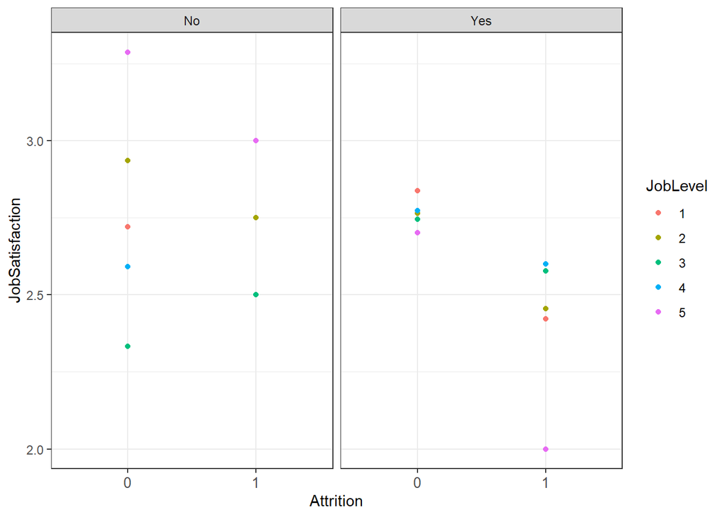

```r
df %>%
  group_by(JobLevel, Attrition, Training) %>%
  summarise(JobSatisfaction = mean(as.numeric(JobSatisfaction))) %>%
  ggplot(mapping = aes(x = Attrition, y = JobSatisfaction, color = JobLevel)) +
    geom_point() +
    facet_grid(. ~ Training) +
  theme_bw() +
  theme(axis.text.x = element_text(size = 10, angle = 0))
```

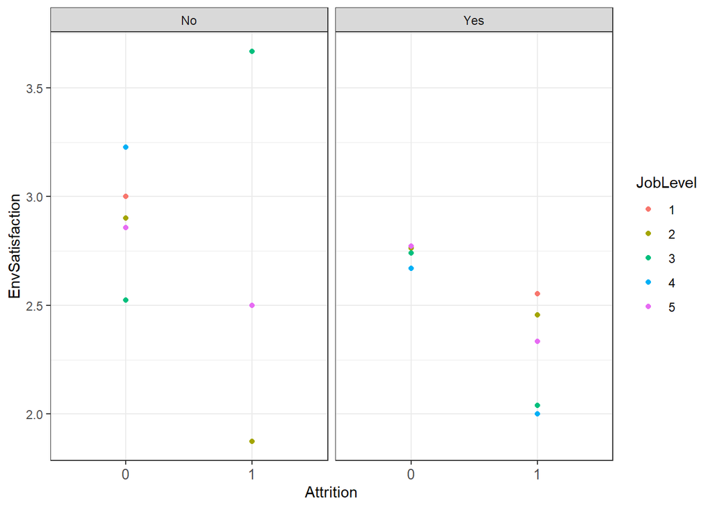

```r
df %>%
  group_by(JobLevel, Attrition, Training) %>%
  summarise(EnvSatisfaction = mean(as.numeric(EnvironmentSatisfaction))) %>%
  ggplot(mapping = aes(x = Attrition, y = EnvSatisfaction, color = JobLevel)) +
    geom_point() +
    facet_grid(. ~ Training) +
  theme_bw() +
  theme(axis.text.x = element_text(size = 10, angle = 0))
```

```r
 demo <- df %>% group_by(Training, Attrition) %>% summarise(med_inc = median(MonthlyIncome),
                                                                                                           n = n()) %>% ungroup()
 sub_title = paste0("Employees who leave with attrion have the least monthly income")

 demo<-demo %>% mutate(scenario = as.factor(paste(Training,Attrition)),
                              scenario = factor(scenario,
                                                levels = c("No 0","No 1","Yes 0","Yes 1"),
                                                labels = c('NoTraining & NoAttrition', 'NoTraining & Attrition',"Training & NoAttrition", "Training & Attrition")
                              )
 )
```